# Quality control and region-level features of TCGA-BRCA DNA methylation data

Illumina 450k array, training set

Group 2: Multiomics - Parniyan, Sergi, Baizhen, Paula, Yueling

12 November 2026

# 1 Overview

This report documents the quality control (QC), normalisation and feature construction of the **DNA methylation data (Illumina 450k array) of the TCGA-BRCA training set**. The array measures about 485,000 CpG sites; the aim is to remove unreliable samples and probes, correct the technical bias between the two probe designs, and summarise the CpGs into a smaller number of **region-level features** (gene promoters, gene bodies and CpG islands) that can be used in the models.

**Data**

- Input: `data/data_split/meth.train.rds`, with one row per patient and one column per CpG, and the clinical data `clin.train.rds`.
- Values: **beta values**, the proportion of methylated DNA at each CpG (0 = unmethylated, 1 = fully methylated).
- Output (written by `02_qc_meth.R`): region-level beta values and M-values (`meth.train.region_beta.rds`, `meth.train.region_M.rds`), the BMIQ-normalised CpG-level betas (`meth.train.cpg_beta.rds`) and the QC parameters (`meth_qc_params.rds`: CpGs kept and region definitions), used to apply exactly the same steps to the test set.

**Steps**

1. Sample QC: missing values per sample and sex check.
2. Probe filters based on the annotation (identical for any dataset): non-CpG probes, sex chromosomes, SNPs and cross-reactive probes.
3. Data-driven probe filter: probes with many missing values (defined on the training set).
4. QC plots: variability, duplicated samples, beta distributions, PCA and batch.
5. BMIQ normalisation of the probe-type bias.
6. Mean methylation per promoter, gene body and CpG island, and transformation to M-values.

**BMIQ in this report**: BMIQ takes about 9 hours, so the report reuses the BMIQ-normalised data saved by the R script (`meth.train.cpg_beta.rds`). It only runs BMIQ if that file does not exist. This report does not overwrite any file (the saving step is shown but not run). Knit it from the project root with `rmarkdown::render("01_data_preprocess/02_qc_meth.Rmd")`.

# 2 Setup

Packages (installation commands, run once), a common plot theme and a helper function used in the report.

```r
BiocManager::install(c("IlluminaHumanMethylation450kanno.ilmn12.hg19",
                       "matrixStats", "wateRmelon"))
install.packages("remotes")
remotes::install_version("RPMM", repos = "https://cran.r-project.org")
```

```r
library(IlluminaHumanMethylation450kanno.ilmn12.hg19)  # probe annotation (chr, type, SNPs, genes)
library(matrixStats)                                   # fast row/column statistics on matrices
library(ggplot2)
```

```r
theme_qc <- function(base_size = 12) {
  theme_classic(base_size = base_size) +
    theme(plot.title    = element_text(face = "bold"),
          plot.subtitle = element_text(colour = "grey40", size = 9),
          legend.position = "top")
}
```

The barplot helper groups the proportion of missing values in bins (green = no missing, blue = some missing, red = high missingness).

```r
plot_na_bins <- function(na_frac, title, x_lab, step = 0.05, max_frac = 1) {
  upper  <- seq(step, max_frac, by = step)
  breaks <- c(-Inf, 0, upper, if (max_frac < 1) Inf)
  labels <- c("0%", paste0(round(100 * (upper - step)), "-", round(100 * upper), "%"),
              if (max_frac < 1) paste0("> ", round(100 * max_frac), "%"))
  df <- as.data.frame(table(bin = cut(na_frac, breaks = breaks, labels = labels)))
  df$pct <- df$Freq / sum(df$Freq)

  n_bins   <- nrow(df)
  high_lab <- if (max_frac < 1) paste0("> ", round(100 * max_frac), "% missing") else "> 90% missing"
  is_high  <- if (max_frac < 1) seq_len(n_bins) == n_bins else c(0, upper) > 0.9
  df$group <- factor(ifelse(seq_len(n_bins) == 1, "No missing",
                            ifelse(is_high, high_lab, "Some missing")),
                     levels = c("No missing", "Some missing", high_lab))

  ggplot(df, aes(bin, Freq, fill = group)) +
    geom_col(width = 0.8) +
    geom_text(data = subset(df, Freq > 0),
              aes(label = sprintf("%d\n(%.0f%%)", Freq, 100 * pct)),
              vjust = -0.2, size = 2.6, lineheight = 0.85) +
    scale_fill_manual(values = c("#1A9850", "#2C7FB8", "#D73027"), name = NULL, drop = FALSE) +
    scale_y_continuous(expand = expansion(mult = c(0, 0.18))) +
    labs(title = title, subtitle = sprintf("n = %d", length(na_frac)),
         x = x_lab, y = "Count") +
    theme_qc() +
    theme(axis.text.x = element_text(angle = 45, hjust = 1))
}
```

# 3 Data loading

The data are converted to a numeric matrix right after reading, because the fast matrix functions (`colVars`, `rowMedians`, …) need a matrix, not a data frame.

```r
path.x <- "./data/data_split"

df <- readRDS(file.path(path.x, "meth.train.rds"))
meth <- as.matrix(df[, colnames(df) != "patientID"])   # drop the ID column (not numeric)
rownames(meth) <- df$patientID                         # patient IDs as row names
rm(df); gc()                                           # free memory (the data are large)
```

```
##             used   (Mb) gc trigger   (Mb)  max used   (Mb)
## Ncells  12961843  692.3   20120278 1074.6  20120278 1074.6
## Vcells 256660538 1958.2  568218621 4335.2 473524894 3612.8
```

```r
clin <- readRDS(file.path(path.x, "clin.train.rds"))
clin <- clin[rownames(meth), ]                         # same patients, same order

class(meth); dim(meth)
```

```
## [1] "matrix" "array"
```

```
## [1]    436 485577
```

# 4 Probe annotation

The Illumina annotation gives, for each probe, its chromosome, its design type (I or II), the SNPs near the CpG and the genes and gene regions it belongs to. It is used for the probe filters and to build the region-level features.

```r
anno <- as.data.frame(getAnnotation(IlluminaHumanMethylation450kanno.ilmn12.hg19))
anno <- anno[intersect(colnames(meth), rownames(anno)), ]   # only probes present in our data

x_probes <- rownames(anno)[which(anno$chr == "chrX")]
y_probes <- rownames(anno)[which(anno$chr == "chrY")]
```

# 5 Sample-level QC

Each sample is assessed with its own data only.

## 5.1 Missing values per probe

Proportion of samples with a missing value for each probe. Probes with missing values in more than 20% of the samples are not used to assess the samples (step below).

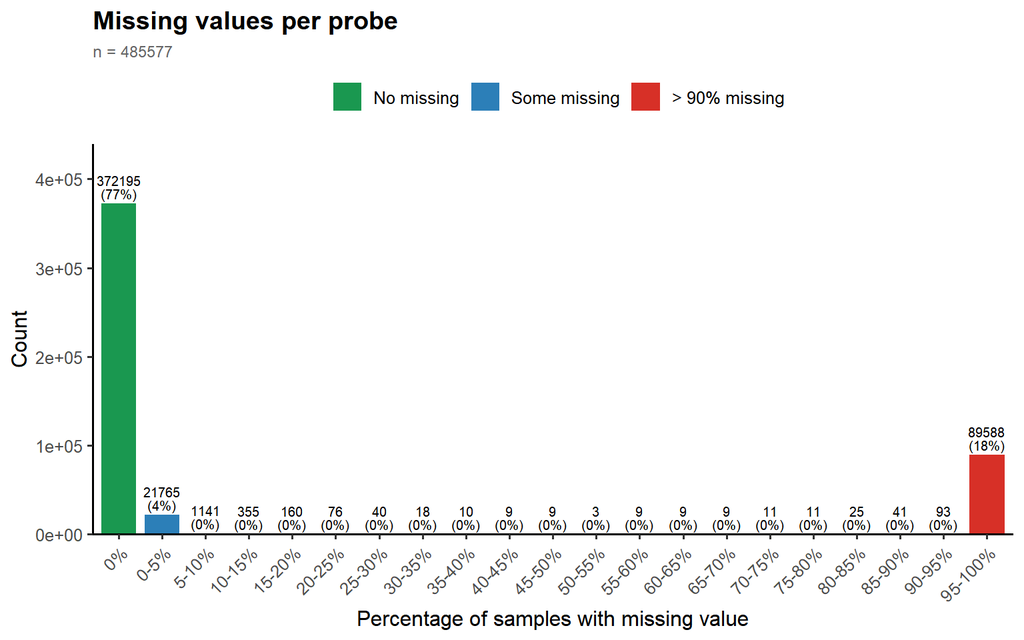

```r
na_probe <- colMeans(is.na(meth))
plot_na_bins(na_probe, "Missing values per probe",
             "Percentage of samples with missing value")
```

## 5.2 Missing values per sample

With the remaining probes (measured in at least 80% of the samples), the missing rate per sample reflects the quality of the sample (e.g. poor DNA or a failed hybridisation). Samples with **more than 5% missing probes** are flagged as low quality.

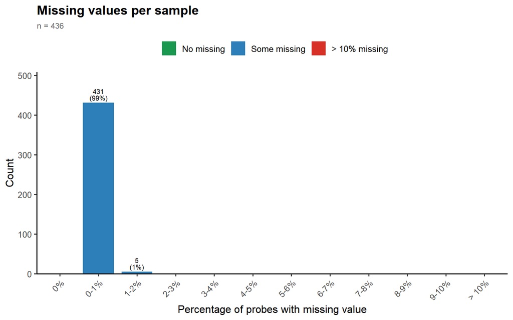

```r
qc_probes <- names(na_probe)[na_probe <= 0.2]
na_sample <- rowMeans(is.na(meth[, qc_probes]))
plot_na_bins(na_sample, "Missing values per sample",
             "Percentage of probes with missing value", step = 0.01, max_frac = 0.10)
```

```r
# Samples with more than 5% missing probes are flagged as low quality
bad_samples <- names(na_sample)[na_sample > 0.05]
bad_samples
```

```
## character(0)
```

0 sample(s) are flagged as low quality.

## 5.3 Sex check

All patients are female, so they should form a single cloud: probes on chromosome Y give only background signal, and probes on chromosome X show intermediate methylation (because one X chromosome is inactivated in females). A sample far from the cloud could be a sample swap. This check must be done before the X and Y probes are removed.

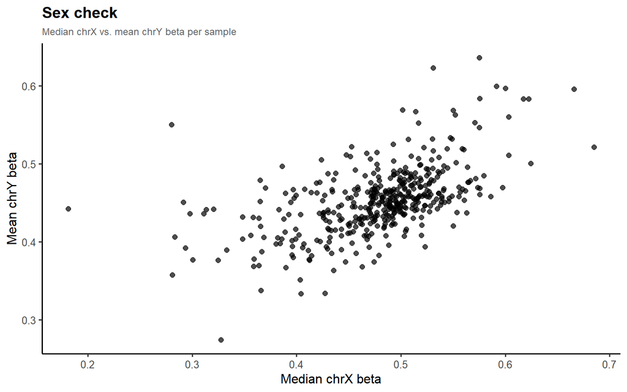

```r
sex_check <- data.frame(patientID = rownames(meth),
                        x_median  = rowMedians(meth[, x_probes], na.rm = TRUE),
                        y_mean    = rowMeans(meth[, y_probes], na.rm = TRUE))

ggplot(sex_check, aes(x = x_median, y = y_mean)) +
  geom_point(size = 2, alpha = 0.7) +
  labs(title = "Sex check",
       subtitle = "Median chrX vs. mean chrY beta per sample",
       x = "Median chrX beta", y = "Mean chrY beta") +
  theme_qc()
```

## 5.4 Remove low-quality samples

The samples flagged above are removed. If any sample is removed here, it should also be removed from the RNA and protein data to keep the datasets aligned.

```r
meth <- meth[!rownames(meth) %in% bad_samples, , drop = FALSE]
clin <- clin[rownames(meth), ]
# If samples are removed, also remove them from rna and prot to keep all datasets aligned
```

# 6 Probe filtering based on the annotation

These filters only use the probe annotation, not the measured values, so they are identical for the training and the test sets.

## 6.1 Non-CpG probes

Probes starting with “ch.” measure non-CpG (CpH) methylation, and “rs.” probes are SNP controls; neither measures CpG methylation.

```r
non_cpg <- colnames(meth)[!grepl("^cg", colnames(meth))]
```

## 6.2 Sex-chromosome probes

Methylation on X and Y differs strongly by sex and by X inactivation, and Y probes are only noise in females.

```r
sex_chr <- c(x_probes, y_probes)
```

## 6.3 SNP-affected probes

A common SNP (minor allele frequency ≥ 1%) at the CpG site or at the single-base extension position changes the measured signal, so the genotype of the patient would look like a change in methylation.

```r
snp_probes <- rownames(anno)[which(anno$CpG_maf >= 0.01 | anno$SBE_maf >= 0.01)]
```

## 6.4 Cross-reactive probes

Probes that also hybridise to other locations of the genome (non-specific probes, Chen et al., 2013) measure a mixture of signals and are removed.

```r
url  <- "https://raw.githubusercontent.com/sirselim/illumina450k_filtering/master/48639-non-specific-probes-Illumina450k.csv"
chen <- read.csv(url)
xreactive <- if ("TargetID" %in% names(chen)) chen$TargetID else chen[, 1]
length(xreactive)
```

```
## [1] 29233
```

## 6.5 Remove the annotation-based probes

The table shows how many probes each reason flags (a probe can have several reasons) and the total removed.

```r
remove_probes <- unique(c(non_cpg, sex_chr, snp_probes, xreactive))

# Summary table: probes flagged by each reason (a probe can have several reasons)
data.frame(reason = c("Non-CpG (ch./rs.)", "Sex chromosomes", "SNP at CpG/SBE (MAF >= 1%)",
                      "Cross-reactive", "Total removed (unique)"),
           probes = c(length(non_cpg), length(sex_chr), length(snp_probes),
                      sum(xreactive %in% colnames(meth)),
                      sum(colnames(meth) %in% remove_probes)))
```

| reason | probes |
| --- | --- |
| Non-CpG (ch./rs.) | 3156 |
| Sex chromosomes | 11648 |
| SNP at CpG/SBE (MAF >= 1%) | 17302 |
| Cross-reactive | 29233 |
| Total removed (unique) | 58414 |

```r
meth <- meth[, !colnames(meth) %in% remove_probes]          # probes are COLUMNS
anno <- anno[intersect(colnames(meth), rownames(anno)), ]   # keep annotation in sync
gc()
```

```
##             used   (Mb) gc trigger   (Mb)  max used   (Mb)
## Ncells  15511579  828.5   30049120 1604.8  20120278 1074.6
## Vcells 285856656 2181.0  825987641 6301.8 740431337 5649.1
```

```r
dim(meth)
```

```
## [1]    436 427163
```

# 7 Data-driven probe filtering

## 7.1 Probes with many missing values

Probes with missing values in more than 20% of the samples are removed. This threshold is set on the training set, and the list of kept CpGs is saved to filter the test set in the same way.

```r
na_probe <- colMeans(is.na(meth))
sum(na_probe > 0.2)                      # number of probes removed
```

```
## [1] 59770
```

```r
meth     <- meth[, na_probe <= 0.2]
gc()
```

```
##             used   (Mb) gc trigger   (Mb)  max used   (Mb)
## Ncells  15511457  828.5   30049120 1604.8  20120278 1074.6
## Vcells 259620245 1980.8  825987641 6301.8 740431337 5649.1
```

After the probe filters, **367,393 CpGs** and **436 patients** are kept.

# 8 QC plots on the filtered data

## 8.1 Most variable probes

The 5,000 most variable probes capture the main structure of the data and make the correlation between samples much faster than using all probes. The histogram shows the standard deviation of all probes; the lines mark the 5,000 and 10,000 most variable ones.

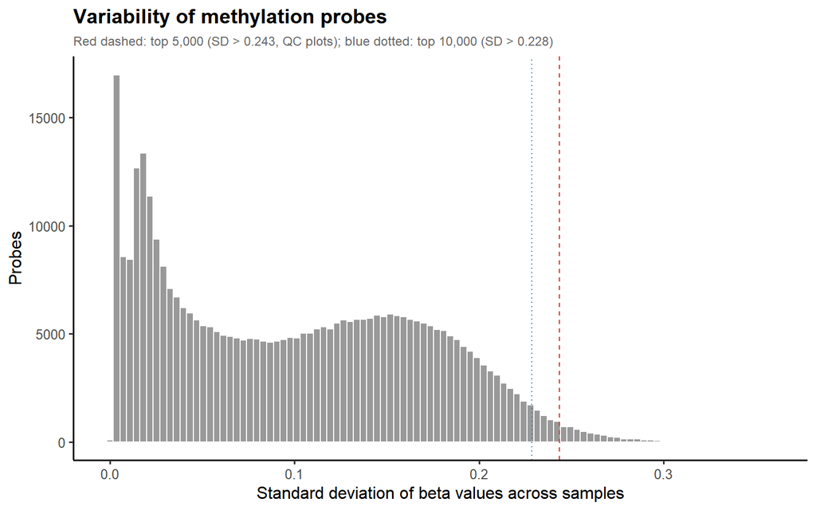

```r
probe_var <- colVars(meth, na.rm = TRUE)
top_var   <- colnames(meth)[order(probe_var, decreasing = TRUE)[1:5000]]

# Distribution of probe variability (SD is on the same scale as beta values)
probe_sd <- sqrt(probe_var)
cut_5k   <- sort(probe_sd, decreasing = TRUE)[5000]    # SD of the 5,000th probe
cut_10k  <- sort(probe_sd, decreasing = TRUE)[10000]   # SD of the 10,000th probe

ggplot(data.frame(sd = probe_sd), aes(x = sd)) +
  geom_histogram(bins = 100, fill = "grey60", colour = "white") +
  geom_vline(xintercept = cut_5k,  linetype = "dashed", colour = "#D73027") +
  geom_vline(xintercept = cut_10k, linetype = "dotted", colour = "#2C7FB8") +
  labs(title = "Variability of methylation probes",
       subtitle = sprintf("Red dashed: top 5,000 (SD > %.3f, QC plots); blue dotted: top 10,000 (SD > %.3f)",
                          cut_5k, cut_10k),
       x = "Standard deviation of beta values across samples", y = "Probes") +
  theme_qc()
```

## 8.2 Duplicated or mixed-up samples

Two different patients should never have near-identical methylation profiles. Pairs of samples with a correlation above 0.99 would suggest a duplicated sample. The histogram shows, for each sample, its highest correlation with any other sample: values close to 1 suggest duplicates, and values far to the left a sample unlike any other.

```r
cor_mat <- cor(t(meth[, top_var]), use = "pairwise.complete.obs")   # sample x sample
diag(cor_mat) <- NA                                                 # ignore self-correlation

dup_pairs <- which(cor_mat > 0.99, arr.ind = TRUE)
dup_pairs <- dup_pairs[dup_pairs[, 1] < dup_pairs[, 2], , drop = FALSE]   # each pair once
data.frame(sample1 = rownames(cor_mat)[dup_pairs[, 1]],
           sample2 = colnames(cor_mat)[dup_pairs[, 2]],
           r       = cor_mat[dup_pairs])
```

| sample1 | sample2 | r |
| --- | --- | --- |

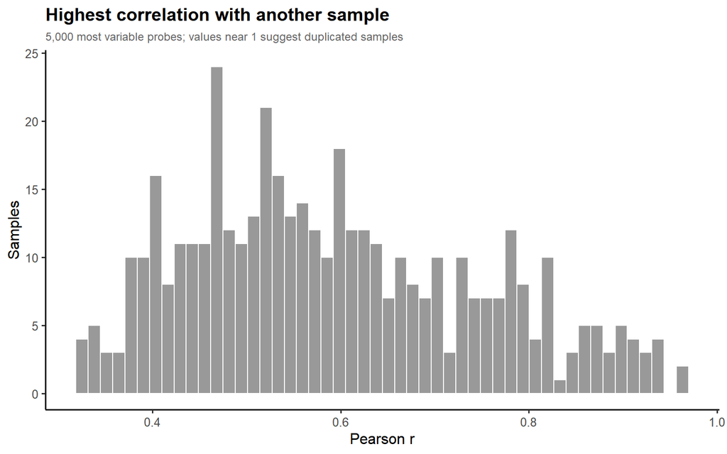

```r
# Highest correlation of each sample with any other sample:
# near 1 = possible duplicate; far left = sample unlike any other (check it)
max_cor <- data.frame(patientID = rownames(cor_mat),
                      max_r     = apply(cor_mat, 1, max, na.rm = TRUE))

ggplot(max_cor, aes(x = max_r)) +
  geom_histogram(bins = 50, fill = "grey60", colour = "white") +
  labs(title = "Highest correlation with another sample",
       subtitle = "5,000 most variable probes; values near 1 suggest duplicated samples",
       x = "Pearson r", y = "Samples") +
  theme_qc()
```

## 8.3 Beta value distributions

Beta values should be **bimodal**, with one peak near 0 (unmethylated CpGs) and one near 1 (methylated CpGs). A sample with a flattened or shifted curve may have technical problems. Samples whose unmethylated peak is low (density below 2.5) are highlighted in red.

```r
grid <- seq(0, 1, length.out = 256)   # common x positions for all densities

# Density of each sample on the common grid (one column per sample)
dens_mat <- apply(meth, 1, function(x) {
  density(x, na.rm = TRUE, from = 0, to = 1, n = 256)$y
})

# Long format for ggplot: one row per (sample, beta value)
dens_df <- data.frame(beta      = rep(grid, ncol(dens_mat)),
                      density   = as.vector(dens_mat),
                      patientID = rep(colnames(dens_mat), each = length(grid)))

# Height of the unmethylated peak per sample: maximum density for beta <= 0.1
low_zone  <- grid <= 0.1
peak_low  <- apply(dens_mat[low_zone, ], 2, max)

# Flag samples with a low (shifted) unmethylated peak
peak_cut <- 2.5
flagged  <- names(peak_low)[peak_low < peak_cut]
length(flagged)
```

```
## [1] 10
```

```r
flagged
```

```
##  [1] "TCGA-E9-A1RD" "TCGA-E9-A22E" "TCGA-BH-A209" "TCGA-E9-A22D" "TCGA-E9-A1RC" "TCGA-E9-A228" "TCGA-E9-A1RF" "TCGA-E9-A226" "TCGA-D8-A1Y3" "TCGA-E9-A1N3"
```

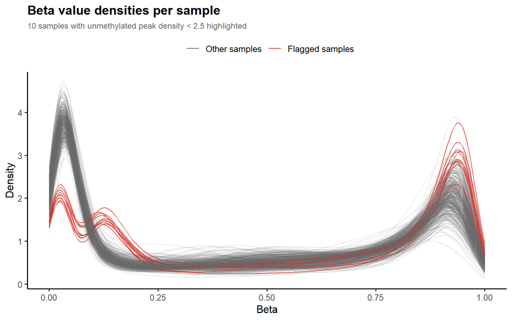

```r
# Highlight the flagged samples in the density plot
dens_df$flagged <- dens_df$patientID %in% flagged

ggplot(dens_df, aes(x = beta, y = density, group = patientID, colour = flagged)) +
  geom_line(aes(alpha = flagged), linewidth = 0.4) +
  scale_colour_manual(values = c(`FALSE` = "grey40", `TRUE` = "#D73027"),
                      labels = c("Other samples", "Flagged samples"), name = NULL) +
  scale_alpha_manual(values = c(`FALSE` = 0.15, `TRUE` = 0.8), guide = "none") +
  labs(title = "Beta value densities per sample",
       subtitle = sprintf("%d samples with unmethylated peak density < %.1f highlighted",
                          length(flagged), peak_cut),
       x = "Beta", y = "Density") +
  theme_qc()
```

10 sample(s) have a low or shifted unmethylated peak. They are kept, and the next section checks whether they are concentrated in some array plates (batch effect).

## 8.4 PCA

Main structure of the data, coloured by stage and by clinical variables. `prcomp()` does not accept missing values, so only the probes without any missing value are used.

```r
pc_dat <- meth[, colSums(is.na(meth)) == 0]       # all probes without any NA
dim(pc_dat)
```

```
## [1]    436 346115
```

```r
pc <- prcomp(pc_dat)
rm(pc_dat); gc()
```

```
##             used   (Mb) gc trigger   (Mb)  max used   (Mb)
## Ncells  15514403  828.6   30049120 1604.8  20120278 1074.6
## Vcells 412516472 3147.3  991265169 7562.8 941593371 7183.8
```

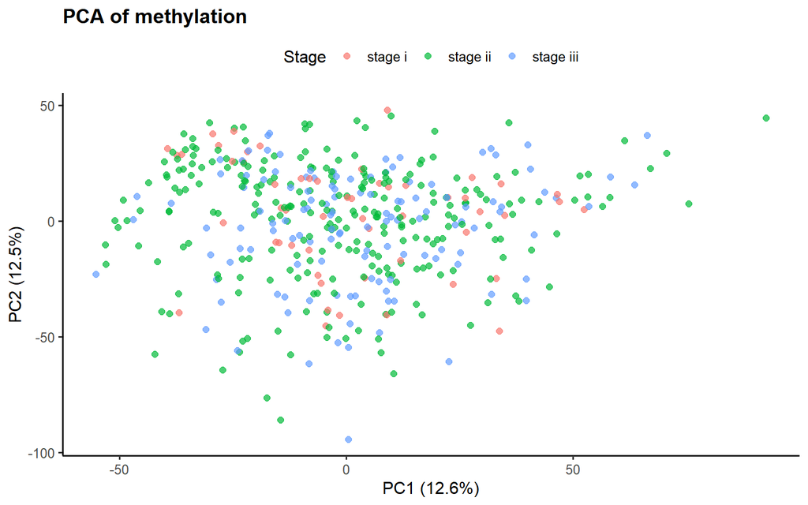

```r
var_exp <- round(100 * summary(pc)$importance[2, 1:2], 1)  # % variance of PC1 and PC2

# PCA coloured by pathological stage (outcome)
pca_df <- data.frame(PC1   = pc$x[, 1],
                     PC2   = pc$x[, 2],
                     stage = clin[rownames(meth), "outcome_p.stage"])

ggplot(pca_df, aes(x = PC1, y = PC2, colour = stage)) +
  geom_point(size = 2, alpha = 0.7) +
  labs(title = "PCA of methylation",
       x = paste0("PC1 (", var_exp[1], "%)"), y = paste0("PC2 (", var_exp[2], "%)"),
       colour = "Stage") +
  theme_qc()
```

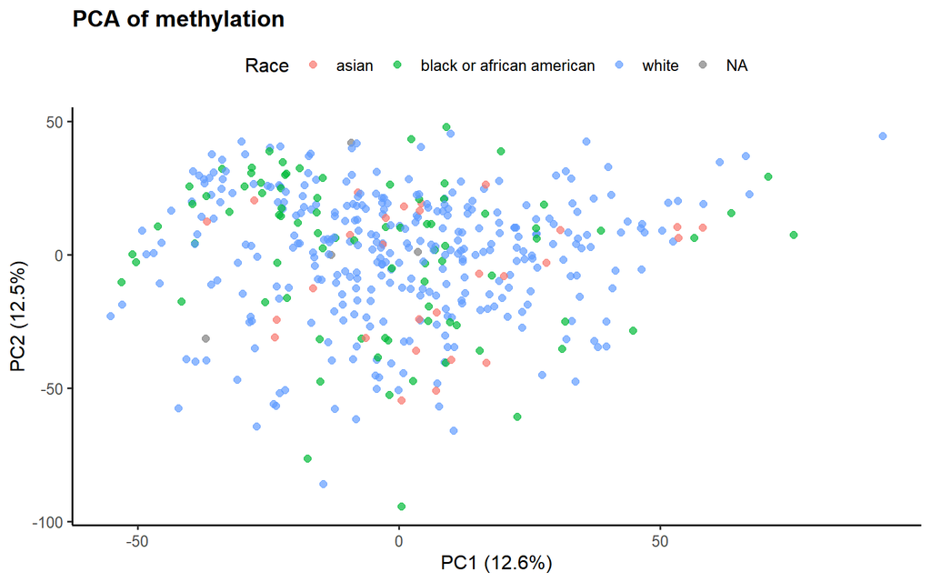

```r
# PCA coloured by race
pca_df <- data.frame(PC1   = pc$x[, 1],
                     PC2   = pc$x[, 2],
                     stage = clin[rownames(meth), "race"])

ggplot(pca_df, aes(x = PC1, y = PC2, colour = stage)) +
  geom_point(size = 2, alpha = 0.7) +
  labs(title = "PCA of methylation",
       x = paste0("PC1 (", var_exp[1], "%)"), y = paste0("PC2 (", var_exp[2], "%)"),
       colour = "Race") +
  theme_qc()
```

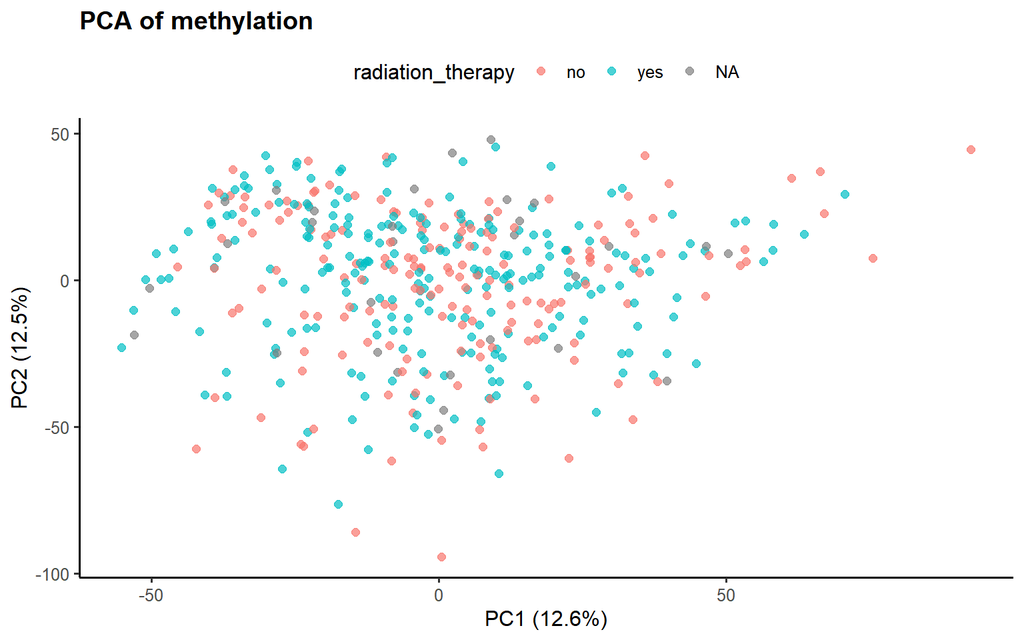

```r
# PCA coloured by radiation therapy
pca_df <- data.frame(PC1   = pc$x[, 1],
                     PC2   = pc$x[, 2],
                     stage = clin[rownames(meth), "radiation_therapy"])

ggplot(pca_df, aes(x = PC1, y = PC2, colour = stage)) +
  geom_point(size = 2, alpha = 0.7) +
  labs(title = "PCA of methylation",
       x = paste0("PC1 (", var_exp[1], "%)"), y = paste0("PC2 (", var_exp[2], "%)"),
       colour = "radiation_therapy") +
  theme_qc()
```

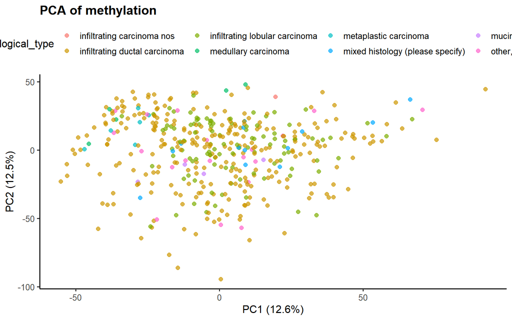

```r
# PCA coloured by histological type
pca_df <- data.frame(PC1   = pc$x[, 1],
                     PC2   = pc$x[, 2],
                     stage = clin[rownames(meth), "histological_type"])

ggplot(pca_df, aes(x = PC1, y = PC2, colour = stage)) +
  geom_point(size = 2, alpha = 0.7) +
  labs(title = "PCA of methylation",
       x = paste0("PC1 (", var_exp[1], "%)"), y = paste0("PC2 (", var_exp[2], "%)"),
       colour = "histological_type") +
  theme_qc()
```

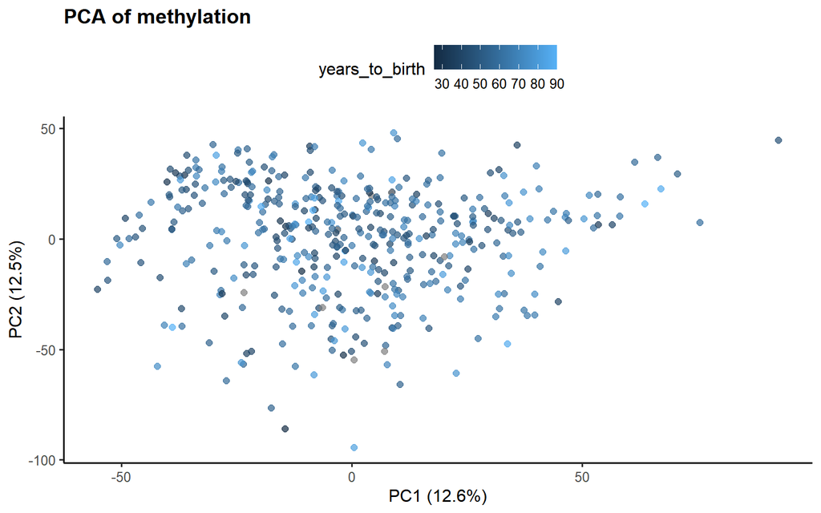

```r
# PCA coloured by age (years_to_birth)
pca_df <- data.frame(PC1   = pc$x[, 1],
                     PC2   = pc$x[, 2],
                     stage = clin[rownames(meth), "years_to_birth"])

ggplot(pca_df, aes(x = PC1, y = PC2, colour = stage)) +
  geom_point(size = 2, alpha = 0.7) +
  labs(title = "PCA of methylation",
       x = paste0("PC1 (", var_exp[1], "%)"), y = paste0("PC2 (", var_exp[2], "%)"),
       colour = "years_to_birth") +
  theme_qc()
```

# 9 Batch information

The array plate is part of the full TCGA sample barcode (characters 22–25), which was trimmed when the data were prepared; it is recovered from curatedTCGAData (cached download). The tissue source site (centre) is in characters 6–7. If the samples with a shifted beta distribution are concentrated in a few plates, or if the PCA separates the samples by plate or centre, there is a batch effect.

```r
library(curatedTCGAData)
library(MultiAssayExperiment)
library(TCGAutils)

# Load only the methylation assay (from cache) to recover the full sample barcodes
mae <- curatedTCGAData(diseaseCode = "BRCA", assays = "Methylation_methyl450",
                       version = "2.1.1", dry.run = FALSE)
barcodes <- colnames(mae[["BRCA_Methylation_methyl450-20160128"]])

batch_info <- data.frame(
  barcode     = barcodes,
  patientID   = substr(barcodes, 1, 12),
  sample_type = substr(barcodes, 14, 15),   # 01 = primary solid tumour
  plate       = substr(barcodes, 22, 25),   # methylation array plate
  centre      = substr(barcodes, 6, 7)      # tissue source site
)
batch_info <- batch_info[batch_info$sample_type == "01", ]           # primary tumours only
batch_info <- batch_info[!duplicated(batch_info$patientID), ]         # one per patient
rownames(batch_info) <- batch_info$patientID

batch_info <- batch_info[rownames(meth), ]   # same patients and order as meth
table(batch_info$plate)
```

```
##
## A10A A10N A10P A12R A138 A13K A145 A14H A14N A161 A16A A16G A17F A17Z A18O A19Z A212 A21R A22B A230 A23D A244 A268 A27Y A28C A29O A31V A32T A33F A357 A36K A41Q
##   22   12   47   31   11   41   18   15   16   16   25   21    7    8   10    4    5    9    8    6    4    8   13    8   13    6    7    6    8    6    6   19
```

```r
rm(mae); gc()
```

```
##             used   (Mb) gc trigger   (Mb)  max used   (Mb)
## Ncells  16273237  869.1   30049120 1604.8  30049120 1604.8
## Vcells 413917961 3158.0  991265169 7562.8 941593371 7183.8
```

```r
# Are the samples with a shifted unmethylated peak concentrated in some plates?
tab <- table(plate = batch_info$plate, flagged = rownames(meth) %in% flagged)
tab[tab[, "TRUE"] > 0, , drop = FALSE]   # plates containing flagged samples
```

```
##       flagged
## plate  FALSE TRUE
##   A161     6   10
```

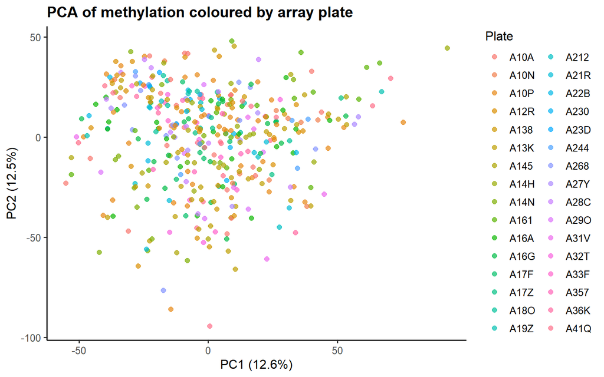

```r
# PCA coloured by plate
pca_df$plate <- batch_info[rownames(pca_df), "plate"]

ggplot(pca_df, aes(x = PC1, y = PC2, colour = plate)) +
  geom_point(size = 2, alpha = 0.7) +
  labs(title = "PCA of methylation coloured by array plate",
       x = paste0("PC1 (", var_exp[1], "%)"), y = paste0("PC2 (", var_exp[2], "%)"),
       colour = "Plate") +
  theme_qc() +
  theme(legend.position = "right")
```

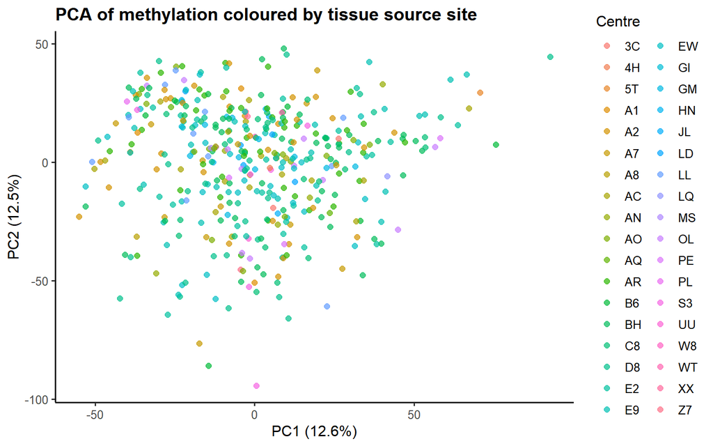

```r
# PCA coloured by tissue source site (centre)
pca_df$centre <- batch_info[rownames(pca_df), "centre"]

ggplot(pca_df, aes(x = PC1, y = PC2, colour = centre)) +
  geom_point(size = 2, alpha = 0.7) +
  labs(title = "PCA of methylation coloured by tissue source site",
       x = paste0("PC1 (", var_exp[1], "%)"), y = paste0("PC2 (", var_exp[2], "%)"),
       colour = "Centre") +
  theme_qc() +
  theme(legend.position = "right")
```

```r
rm(cor_mat, dens_mat, dens_df); gc()
```

```
##             used   (Mb) gc trigger   (Mb)  max used   (Mb)
## Ncells  16597939  886.5   30049120 1604.8  30049120 1604.8
## Vcells 414057502 3159.1  991265169 7562.8 941593371 7183.8
```

# 10 Probe-type bias and BMIQ normalisation

The 450k array uses two probe designs. **Type II probes have a smaller dynamic range** (their peaks are closer to the middle than those of type I probes), so the same methylation level gives different values depending on the design. **BMIQ** adjusts the distribution of the type II probes to that of the type I probes, sample by sample. Because each sample is normalised with its own data only, there is no leakage between samples; the test set is normalised in the same way.

BMIQ is slow: about 9.3 hours on the test computer (11th Gen Intel Core i7-1185G7, 4 cores / 8 threads with 7 used in parallel, 16 GB RAM, Windows, R 4.3.2). This report **reuses the normalised data** saved by the R script, and only runs BMIQ if that file does not exist. The plot compares the median beta per probe of the two designs before and after BMIQ: after the normalisation, both designs should have similar distributions.

```r
type <- anno[colnames(meth), "Type"]

# Median beta per probe BEFORE normalisation
type_before <- data.frame(median_beta = colMedians(meth, na.rm = TRUE),
                          type        = paste("Type", type),
                          step        = "Before BMIQ")

library(RPMM)
library(parallel)

# In this report: reuse the BMIQ-normalised CpGs saved by 02_qc_meth.R
# (data/processed/meth.train.cpg_beta.rds) instead of running BMIQ again (~9 h).
# BMIQ only runs if that file does not exist.
bmiq_file <- "data/processed/meth.train.cpg_beta.rds"
do_bmiq   <- !file.exists(bmiq_file)
if (!do_bmiq) {
  df <- readRDS(bmiq_file)
  saved_bmiq <- as.matrix(df[, colnames(df) != "patientID", drop = FALSE])
  rownames(saved_bmiq) <- df$patientID
  rm(df); gc()
  stopifnot(all(rownames(meth) %in% rownames(saved_bmiq)),
            all(colnames(meth) %in% colnames(saved_bmiq)))
  meth <- saved_bmiq[rownames(meth), colnames(meth)]   # same patients and CpGs as now
  rm(saved_bmiq); gc()
}
```

```
##             used   (Mb) gc trigger   (Mb)  max used   (Mb)
## Ncells  16187300  864.5   30049120 1604.8  30049120 1604.8
## Vcells 414887017 3165.4  991265169 7562.8 941593371 7183.8
```

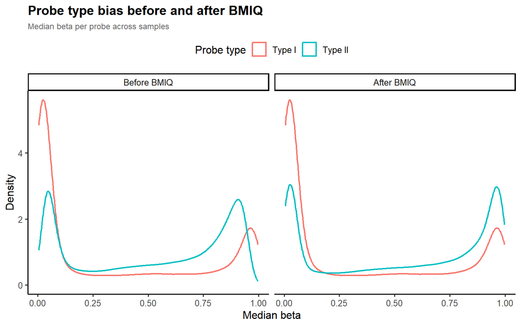

```r
# BMIQ normalisation in parallel (one sample per task; samples are independent)
if (do_bmiq) {
  design_v <- ifelse(type == "I", 1, 2)

  # Normalise one block of samples (rows); failed samples are left unchanged
  bmiq_block <- function(m, design_v) {
    for (i in seq_len(nrow(m))) {
      ok  <- !is.na(m[i, ])
      res <- tryCatch(
        wateRmelon::BMIQ(m[i, ok], design_v[ok], plots = FALSE, pri = FALSE)$nbeta,
        error = function(e) NULL
      )
      if (!is.null(res)) m[i, ok] <- res
    }
    m
  }

  # Split the samples into one block per core and run the blocks in parallel
  n_cores <- max(1, detectCores() - 1)           # leave one core free
  blocks  <- split(seq_len(nrow(meth)), cut(seq_len(nrow(meth)), n_cores, labels = FALSE))
  chunks  <- lapply(blocks, function(i) meth[i, , drop = FALSE])

  cl <- makeCluster(n_cores)
  clusterEvalQ(cl, { library(wateRmelon); library(RPMM) })
  t0 <- Sys.time()
  res <- parLapply(cl, chunks, bmiq_block, design_v = design_v)
  stopCluster(cl)
  print(Sys.time() - t0)

  meth <- do.call(rbind, res)[rownames(meth), ]   # same sample order as before
  rm(chunks, res); gc()
}

# Median beta per probe AFTER normalisation
type_after <- data.frame(median_beta = colMedians(meth, na.rm = TRUE),
                         type        = paste("Type", type),
                         step        = "After BMIQ")

# Combine before and after, and plot side by side
type_df <- rbind(type_before, type_after)
type_df$step <- factor(type_df$step, levels = c("Before BMIQ", "After BMIQ"))

ggplot(type_df, aes(x = median_beta, colour = type)) +
  geom_density(linewidth = 0.8) +
  facet_wrap(~ step) +
  labs(title = "Probe type bias before and after BMIQ",
       subtitle = "Median beta per probe across samples",
       x = "Median beta", y = "Density", colour = "Probe type") +
  theme_qc()
```

# 11 Region-level methylation

Neighbouring CpGs usually have similar methylation, and a single CpG is a noisy measurement. The CpGs are therefore summarised as the **mean beta of the CpGs in each region**, ignoring missing values:

- **Promoter**: CpGs in TSS1500, TSS200, 5’UTR or the first exon of a gene (Illumina annotation).
- **Gene body**: CpGs in the body or the 3’UTR of a gene.
- **CpG island**: CpGs located in an island, grouped by island.

This summarises the CpG sites into regions (one value per gene promoter, gene body or island).

```r
library(Matrix)

min_probes <- 1   # minimum number of CpGs in a region (from the annotation)
min_obs    <- 1   # minimum number of non-missing CpGs in a sample for that region

anno_r <- anno[colnames(meth), c("UCSC_RefGene_Name", "UCSC_RefGene_Group",
                                 "Relation_to_Island", "Islands_Name")]
```

## 11.1 Gene promoters and gene bodies

A probe can map to several genes or transcripts. If a probe is in the promoter of one transcript and in the body of another transcript of the same gene, it is counted only in the promoter.

```r
anno_g  <- anno_r[anno_r$UCSC_RefGene_Name != "", ]
genes   <- strsplit(anno_g$UCSC_RefGene_Name,  ";")
regions <- strsplit(anno_g$UCSC_RefGene_Group, ";")
probe_gene <- data.frame(probe  = rep(rownames(anno_g), lengths(genes)),
                         gene   = unlist(genes),
                         region = unlist(regions))

probe_gene$region_type <- ifelse(probe_gene$region %in% c("TSS1500", "TSS200", "5'UTR", "1stExon"), "promoter",
                                 ifelse(probe_gene$region %in% c("Body", "3'UTR"), "body", NA))
probe_gene <- probe_gene[!is.na(probe_gene$region_type), ]

# If a probe is in the promoter of one transcript and the body of another
# transcript of the SAME gene, it is counted only in the promoter
probe_gene <- probe_gene[order(probe_gene$region_type != "promoter"), ]
probe_gene <- probe_gene[!duplicated(probe_gene[, c("probe", "gene")]), ]
```

## 11.2 CpG islands

Only the CpGs located inside a CpG island are used (not the shores or shelves around it), grouped by the island they belong to (Illumina annotation).

```r
probe_island <- data.frame(probe  = rownames(anno_r),
                           island = anno_r$Islands_Name)
probe_island <- probe_island[anno_r$Relation_to_Island == "Island" &
                               probe_island$island != "", ]
```

## 11.3 Region lists

Each region is a list of the CpGs it contains. These lists are saved, so that the test set is summarised with exactly the same regions.

```r
make_list <- function(probes, region_ids) {
  rl <- split(probes, region_ids)
  rl[lengths(rl) >= min_probes]
}

region_lists <- list(
  promoter = with(probe_gene[probe_gene$region_type == "promoter", ], make_list(probe, gene)),
  body     = with(probe_gene[probe_gene$region_type == "body", ],     make_list(probe, gene)),
  island   = with(probe_island,                                       make_list(probe, island))
)
sapply(region_lists, length)   # number of promoters, gene bodies and CpG islands
```

```
## promoter     body   island
##    19355    17186    24831
```

## 11.4 Mean methylation per region

The mean beta is computed for each region. A region is missing (NA) for a patient only if none of its CpGs was measured in that patient.

```r
region_mean <- function(m, rl) {
  A <- sparseMatrix(i    = match(unlist(rl), colnames(m)),
                    j    = rep(seq_along(rl), lengths(rl)),
                    x    = 1,
                    dims = c(ncol(m), length(rl)),
                    dimnames = list(colnames(m), names(rl)))

  obs  <- !is.na(m)          # TRUE where the CpG was measured
  m0   <- m
  m0[!obs] <- 0              # missing values contribute 0 to the sum

  sums   <- as.matrix(m0  %*% A)   # sum of observed betas per sample and region
  counts <- as.matrix(obs %*% A)   # number of observed CpGs per sample and region

  out <- sums / counts             # mean of observed CpGs (= rowMeans with na.rm = TRUE)
  out[counts < min_obs] <- NA      # too few observed CpGs: not reliable
  out
}

# check.names = FALSE keeps the original region names (e.g. "HLA-A", "chr1:123-456")
meth_promoter <- data.frame(region_mean(meth, region_lists$promoter), check.names = FALSE)
meth_body     <- data.frame(region_mean(meth, region_lists$body),     check.names = FALSE)
meth_island   <- data.frame(region_mean(meth, region_lists$island),   check.names = FALSE)
gc()
```

```
##             used   (Mb) gc trigger   (Mb)   max used   (Mb)
## Ncells  17263381  922.0   30049120 1604.8   30049120 1604.8
## Vcells 453810960 3462.4 1189598202 9076.0 1176331553 8974.7
```

## 11.5 Number of features

```r
data.frame(region    = c("Gene promoters", "Gene bodies", "CpG islands"),
           features  = c(ncol(meth_promoter), ncol(meth_body), ncol(meth_island)),
           samples   = c(nrow(meth_promoter), nrow(meth_body), nrow(meth_island)),
           pct_na    = round(100 * c(mean(is.na(meth_promoter)),
                                     mean(is.na(meth_body)),
                                     mean(is.na(meth_island))), 3))
```

| region | features | samples | pct_na |
| --- | --- | --- | --- |
| Gene promoters | 19355 | 436 | 0.020 |
| Gene bodies | 17186 | 436 | 0.036 |
| CpG islands | 24831 | 436 | 0.009 |

## 11.6 Join the three region types

The three region types are joined in one dataset. A suffix (`.promoter`, `.genebody`, `.island`) distinguishes the promoter and the gene body of the same gene.

```r
meth_promoter$patientID <- rownames(meth_promoter)
meth_body$patientID     <- rownames(meth_body)
meth_island$patientID   <- rownames(meth_island)

# Add a suffix to every feature (all columns except patientID), so that the
# promoter and the gene body of the same gene can be distinguished
add_suffix <- function(df, suffix) {
  feat <- colnames(df) != "patientID"
  colnames(df)[feat] <- paste0(colnames(df)[feat], suffix)
  df
}

meth2 <- merge(add_suffix(meth_promoter, ".promoter"),
               add_suffix(meth_body,     ".genebody"), by = "patientID")
meth2 <- merge(meth2, add_suffix(meth_island, ".island"), by = "patientID")

meth2 <- meth2[match(rownames(meth), meth2$patientID), ]
rownames(meth2) <- meth2$patientID
```

# 12 QC of region-level features

## 12.1 Features without missing values

The PCA does not accept missing values, so it uses the region-level features without any NA.

```r
X <- as.matrix(meth2[, colnames(meth2) != "patientID"])
rownames(X) <- meth2$patientID
X <- X[, colSums(is.na(X)) == 0]          # PCA does not accept NAs

feature_type <- sub(".*\\.", "", colnames(X))   # promoter / genebody / island
table(feature_type)
```

```
## feature_type
## genebody   island promoter
##    16810    24701    19128
```

## 12.2 PCA loadings

Centred but not scaled, because all features are on the same scale (mean beta, 0–1). Each point is a feature, coloured by region type; features far from the origin drive the components.

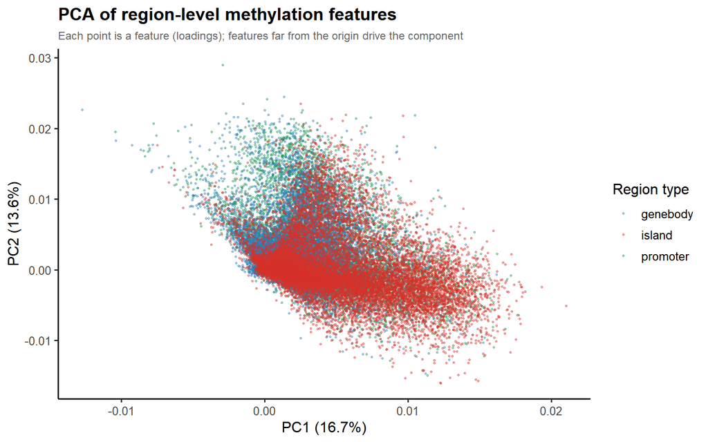

```r
pc      <- prcomp(X, center = TRUE, scale. = FALSE)
var_exp <- round(100 * summary(pc)$importance[2, 1:2], 1)

# Loadings plot: each point is a feature, coloured by region type
load_df <- data.frame(PC1  = pc$rotation[, 1],
                      PC2  = pc$rotation[, 2],
                      type = feature_type)

ggplot(load_df, aes(x = PC1, y = PC2, colour = type)) +
  geom_point(size = 0.6, alpha = 0.4) +
  scale_colour_manual(values = c(promoter = "#1A9850", genebody = "#2C7FB8", island = "#D73027")) +
  labs(title = "PCA of region-level methylation features",
       subtitle = "Each point is a feature (loadings); features far from the origin drive the component",
       x = paste0("PC1 (", var_exp[1], "%)"), y = paste0("PC2 (", var_exp[2], "%)"),
       colour = "Region type") +
  theme_qc() +
  theme(legend.position = "right")
```

## 12.3 Mean methylation and variability by region type

Promoters and CpG islands are usually mostly unmethylated, and gene bodies more methylated. The variability (SD across patients) shows which region types differ more between patients.

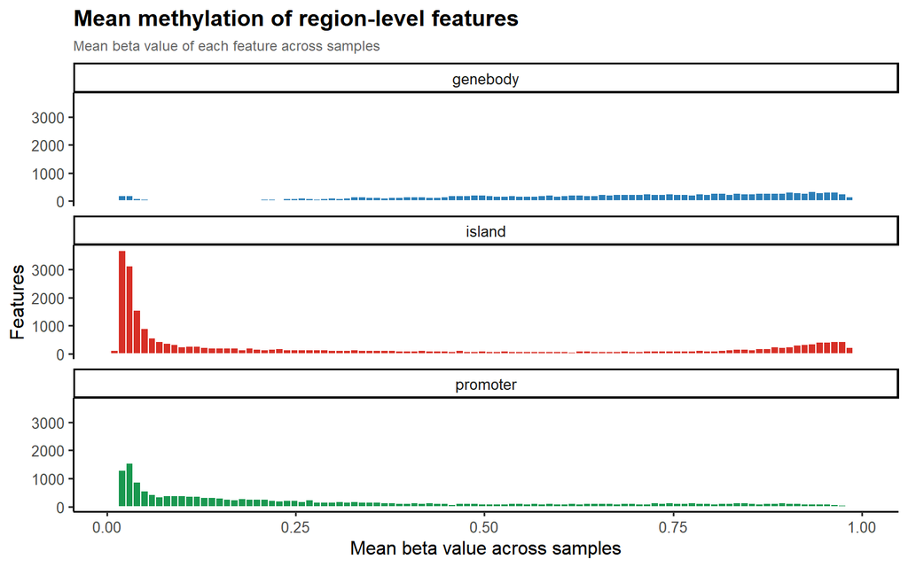

```r
feat_stats <- data.frame(mean = colMeans(X, na.rm = TRUE),
                         sd   = colSds(X, na.rm = TRUE),
                         type = sub(".*\\.", "", colnames(X)))

# Mean beta of each feature across samples
ggplot(feat_stats, aes(x = mean, fill = type)) +
  geom_histogram(bins = 100, colour = "white") +
  facet_wrap(~ type, ncol = 1) +
  scale_fill_manual(values = c(promoter = "#1A9850", genebody = "#2C7FB8", island = "#D73027"),
                    guide = "none") +
  labs(title = "Mean methylation of region-level features",
       subtitle = "Mean beta value of each feature across samples",
       x = "Mean beta value across samples", y = "Features") +
  theme_qc()
```

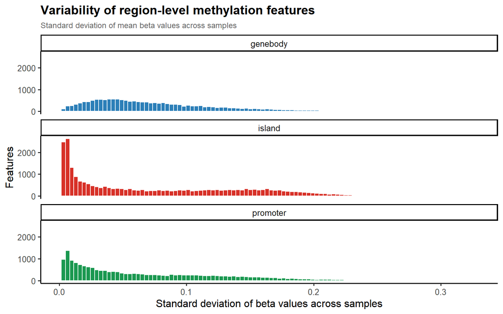

```r
# SD of each feature across samples (same scale as beta values)
ggplot(feat_stats, aes(x = sd, fill = type)) +
  geom_histogram(bins = 100, colour = "white") +
  facet_wrap(~ type, ncol = 1) +
  scale_fill_manual(values = c(promoter = "#1A9850", genebody = "#2C7FB8", island = "#D73027"),
                    guide = "none") +
  labs(title = "Variability of region-level methylation features",
       subtitle = "Standard deviation of mean beta values across samples",
       x = "Standard deviation of beta values across samples", y = "Features") +
  theme_qc()
```

# 13 M-values

Beta values are bounded between 0 and 1, and their variance depends on the mean (it is small near 0 and 1). The **M-value**, M = log2(beta / (1 − beta)), has better statistical properties (a more symmetric distribution and a more constant variance), so it is used in the models. A small offset avoids infinite values at 0 and 1. Trees (random forest, XGBoost) give the same results with beta and M-values, because the transformation keeps the order of the values.

```r
to_M <- function(b, offset = 1e-6) log2((b + offset) / (1 - b + offset))

# All region-level features (NAs kept)
X <- as.matrix(meth2[, names(meth2) != "patientID"])
rownames(X) <- meth2$patientID

methM <- to_M(X)
```

## 13.1 Distribution of random features: beta vs M-values

Four random features per tertile of mean beta are shown on the beta scale, the M-value scale and the standardised M-value scale.

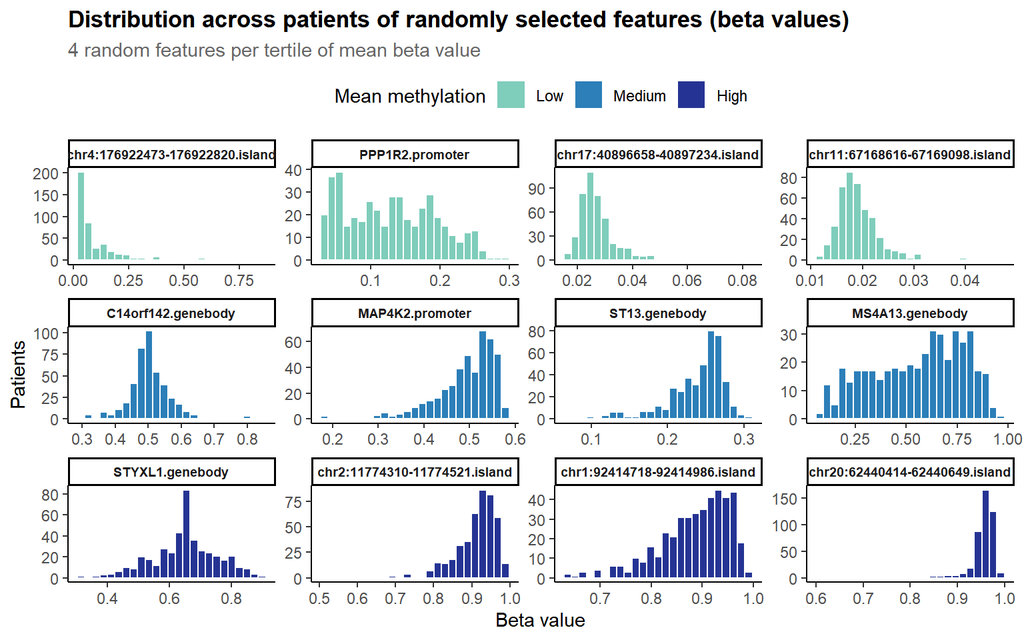

```r
set.seed(1)
feat_mean <- colMeans(X, na.rm = TRUE)
strata    <- cut(feat_mean, quantile(feat_mean, c(0, 1/3, 2/3, 1), na.rm = TRUE),
                 labels = c("Low", "Medium", "High"), include.lowest = TRUE)
pick <- unlist(lapply(split(colnames(methM), strata), sample, size = 4))

# Plot the distribution across patients of the selected features
plot_feature_dist <- function(mat, x_lab, title) {
  feat_df <- data.frame(feature = rep(pick, each = nrow(mat)),
                        stratum = rep(strata[match(pick, colnames(mat))], each = nrow(mat)),
                        value   = as.vector(mat[, pick]))
  feat_df$feature <- factor(feat_df$feature, levels = pick)

  ggplot(feat_df, aes(value, fill = stratum)) +
    geom_histogram(bins = 25, colour = "white", na.rm = TRUE) +
    facet_wrap(~ feature, scales = "free", ncol = 4) +
    scale_fill_manual(values = c(Low = "#7FCDBB", Medium = "#2C7FB8", High = "#253494"),
                      name = "Mean methylation") +
    labs(title = title,
         subtitle = "4 random features per tertile of mean beta value",
         x = x_lab, y = "Patients") +
    theme_classic(base_size = 11) +
    theme(plot.title    = element_text(face = "bold"),
          plot.subtitle = element_text(colour = "grey40"),
          strip.text    = element_text(face = "bold", size = 7),
          legend.position = "top")
}

plot_feature_dist(X,             "Beta value",        "Distribution across patients of randomly selected features (beta values)")
```

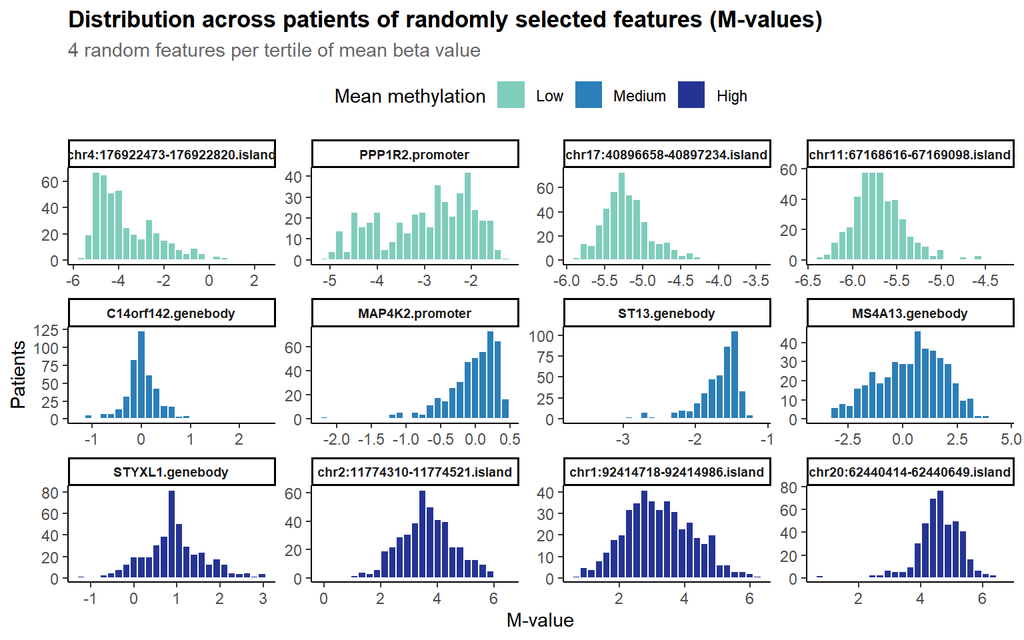

```r
plot_feature_dist(methM,         "M-value",           "Distribution across patients of randomly selected features (M-values)")
```

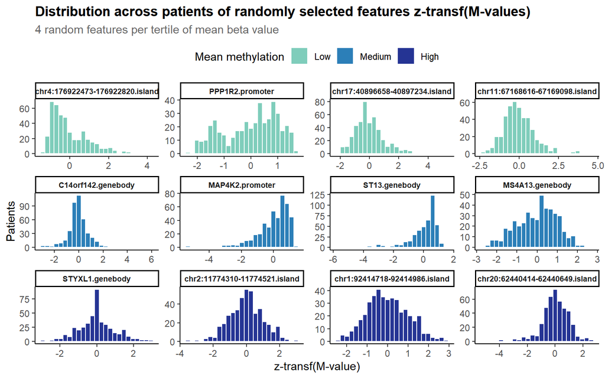

```r
plot_feature_dist(scale(methM),  "z-transf(M-value)", "Distribution across patients of randomly selected features z-transf(M-values)")
```

# 14 Summary

- **0 low-quality sample(s)** were removed, and the probe filters keep **367,393 CpGs**.
- After BMIQ, the CpGs are summarised into **61,372 region-level features** (promoters, gene bodies and CpG islands).
- 10 sample(s) have a shifted beta distribution; their relation with the array plates is shown in the batch section.

# 15 Save

The region-level data, the normalised CpGs and the QC parameters are written by the R script `02_qc_meth.R`. In this report the code is shown but **not run**, so that knitting does not overwrite the processed data (nor the model cache that depends on them).

```r
path.x <- "./data/processed"
dir.create(path.x, showWarnings = FALSE, recursive = TRUE)

# QC parameters learned on train, to apply the same QC to test / Shiny data
# (computed before adding patientID, so only CpG names are stored)
meth_qc_params <- list(
  kept_probes  = colnames(meth),   # CpGs kept after probe filtering (before aggregation)
  region_lists = region_lists,     # CpG-to-region mapping (promoter, body, island)
  min_obs      = min_obs           # Minimum non-NA CpGs per region and sample
)

methM <- data.frame(methM, check.names = FALSE)
methM$patientID <- rownames(methM)
methM <- methM[, c(ncol(methM), 1:(ncol(methM) - 1))]   # patientID as first column

meth_df <- data.frame(meth, check.names = FALSE)
meth_df$patientID <- rownames(meth_df)
meth_df <- meth_df[, c(ncol(meth_df), 1:(ncol(meth_df) - 1))]

saveRDS(meth2,          file.path(path.x, "meth.train.region_beta.rds"))  # region-level beta values
saveRDS(methM,          file.path(path.x, "meth.train.region_M.rds"))     # region-level M-values
saveRDS(meth_df,        file.path(path.x, "meth.train.cpg_beta.rds"))     # CpG-level beta values (filtered, BMIQ)
saveRDS(meth_qc_params, file.path(path.x, "meth_qc_params.rds"))          # QC parameters for test / Shiny

gc()
```